# Reproducible Research - Course Project 1

Deon Engelbrecht

03 November 2016

### Introduction

This is an Peer-graded assignment that is part of the Reproducible Research Course see [link](https://www.coursera.org/learn/reproducible-research).

#### Data Source

The [Activity monitoring data](https://d396qusza40orc.cloudfront.net/repdata%2Fdata%2Factivity.zip%5D%20should%20exit%20in%20the%20working) should be downloaded and placed inside the active directory in a folder called *Data*.

#### Library Includes

```r
library(sqldf)
library(tcltk)
require(sqldf)
library(lattice)
```

#### Data Access

Read the **Activity Monitoring Data** into a variable for processing

```r
activity <- read.csv(file = "./Data/activity.csv", header = TRUE, sep = ",")
activity$date <- as.Date(activity$date, format="%Y-%m-%d")
```

Summry of data:

```r
summary(activity)
```

```
##      steps             date               interval
##  Min.   :  0.00   Min.   :2012-10-01   Min.   :   0.0
##  1st Qu.:  0.00   1st Qu.:2012-10-16   1st Qu.: 588.8
##  Median :  0.00   Median :2012-10-31   Median :1177.5
##  Mean   : 37.38   Mean   :2012-10-31   Mean   :1177.5
##  3rd Qu.: 12.00   3rd Qu.:2012-11-15   3rd Qu.:1766.2
##  Max.   :806.00   Max.   :2012-11-30   Max.   :2355.0
##  NA's   :2304
```

## Part 1:

What is mean total number of steps taken per day?

#### Aggregate Data

Aggregate the data: Sum the **Steps** by **Date**

```r
agg_ByDate <- aggregate(steps ~ date, data = activity, FUN = sum)
```

#### Make Histogram

Show Histogram with Step Frequency

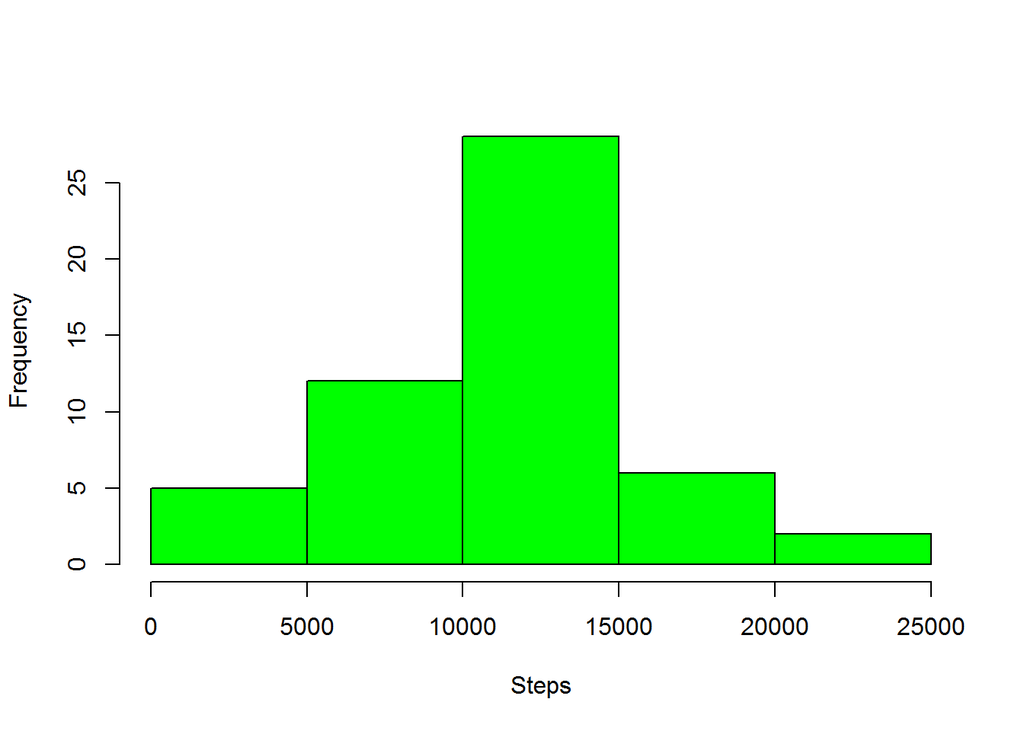

```r
hist(agg_ByDate$steps, main="", xlab="Steps" , ylab = "Frequency", border="black", col="green")
```

#### Summary

The Mean: 10766.1886792453

The Median: 10765

## Part 2:

What is the average daily activity pattern?

#### Aggregate Data

Aggregate the data: Sum the **Steps** by **Interval**

```r
agg_ByInterval <- aggregate(steps ~ interval, data = activity, FUN = sum)
```

#### Make Time Series Plot

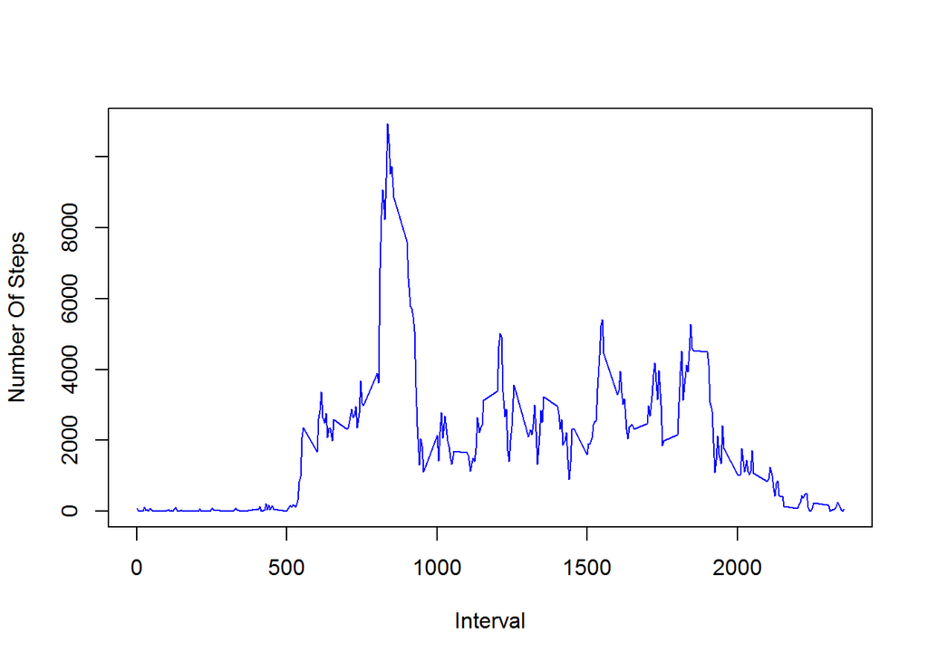

```r
plot(agg_ByInterval, type = "l", col = "blue", ylab = "Number Of Steps", xlab="Interval")
```

#### Highes AVG Steps by Inteval

Roll-up by 5-minute interval, and get the average steps across all the days in the dataset

```r
  agg_AVGInterval <- sqldf("SELECT interval, AVG(steps) as avgSteps from activity GROUP BY interval ORDER BY AVG(steps) DESC")
  agg_AVGInterval <- agg_AVGInterval[1,]
```

The 5-minute inverval that on AVG contains the max number of steps are: 835 with a AVG Total steps of 206.169811320755

## Part 3:

Imputing missing values

*Note that there are a number of days/intervals where there are missing values (coded as NA). The presence of missing days may introduce bias into some calculations or summaries of the data*.

**1. Calculate and report the total number of missing values in the dataset (i.e. the total number of rows with NAs)**

```r
  sum(is.na(activity))
```

```
## [1] 2304
```

**2. Devise a strategy for filling in all of the missing values in the dataset. The strategy does not need to be sophisticated. For example, you could use the mean/median for that day, or the mean for that 5-minute interval, etc.**

```r
  agg_AVGStepsByDay <- sqldf("SELECT date, AVG(steps) as avgSteps from activity GROUP BY date ORDER BY date")

  agg_AVGStepsByDay$avgSteps[is.na(agg_AVGStepsByDay$avgSteps)] <- 0

  activity2 <- activity

  for(i in 1:nrow(activity2)) {

      if(is.na(activity2[i,"steps"])) {
        x <- subset(agg_AVGStepsByDay, date == activity2[i,"date"])$avgSteps
        activity2[i,"steps"] <- x
      }
  }

    activity2$steps <- as.numeric(activity2$steps)
```

**3. Create a new dataset that is equal to the original dataset but with the missing data filled in.** The new data set is activity2:

```r
  summary(activity2)
```

```
##      steps             date               interval
##  Min.   :  0.00   Min.   :2012-10-01   Min.   :   0.0
##  1st Qu.:  0.00   1st Qu.:2012-10-16   1st Qu.: 588.8
##  Median :  0.00   Median :2012-10-31   Median :1177.5
##  Mean   : 32.48   Mean   :2012-10-31   Mean   :1177.5
##  3rd Qu.:  0.00   3rd Qu.:2012-11-15   3rd Qu.:1766.2
##  Max.   :806.00   Max.   :2012-11-30   Max.   :2355.0
```

```r
  head(activity2)
```

```
##   steps       date interval
## 1     0 2012-10-01        0
## 2     0 2012-10-01        5
## 3     0 2012-10-01       10
## 4     0 2012-10-01       15
## 5     0 2012-10-01       20
## 6     0 2012-10-01       25
```

**4. Make a histogram of the total number of steps taken each day and Calculate and report the mean and median total number of steps taken per day. Do these values differ from the estimates from the first part of the assignment? What is the impact of imputing missing data on the estimates of the total daily number of steps?**

#### Make Histogram (activty with cleanup misssing values)

Show Histogram with Step Frequency usig activity2

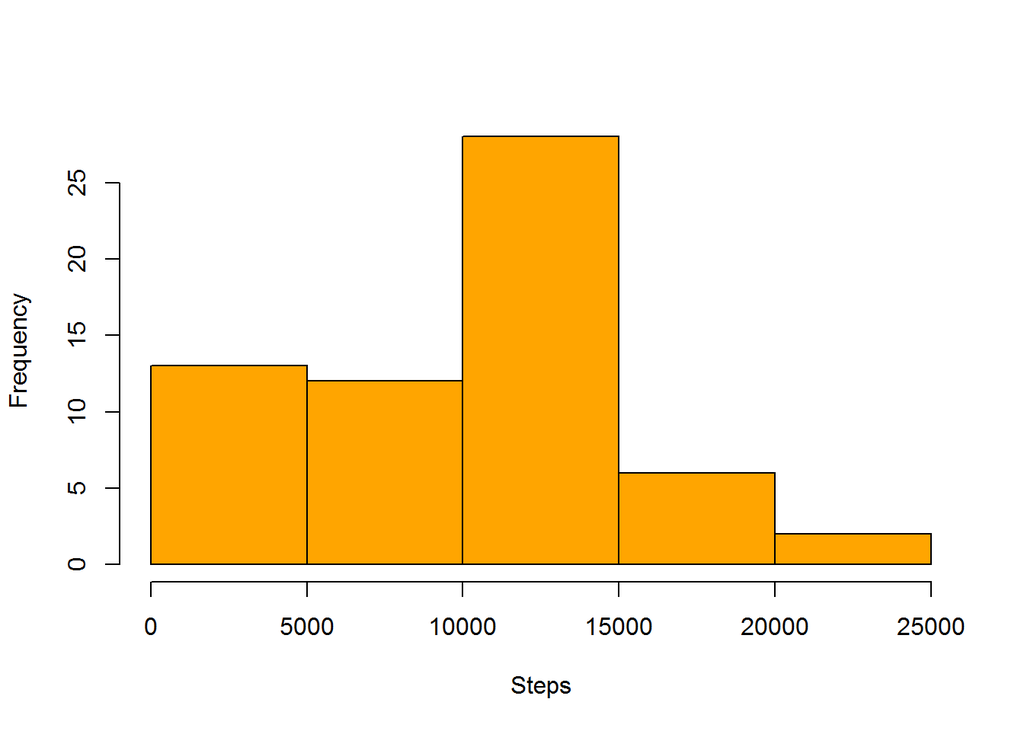

```r
agg_ByDate2 <- aggregate(steps ~ date, data = activity2, FUN = sum)
hist(agg_ByDate2$steps, main="", xlab="Steps" , ylab = "Frequency", border="black", col="orange")
```

#### Summary

The Mean: 9354.22950819672

The Median: 10395

## Part 4:

Are there differences in activity patterns between weekdays and weekends?

```r
  activity2$dayOfWeek <- "weekday"

  for(i in 1:nrow(activity2))
  {
    x <- weekdays(as.Date(activity2[i,"date"]))

    if( x == "Saturday" | x == "Sunday" ) {
        activity2[i,"dayOfWeek"] <- "weekend"
    }

  }
```

#### Aggregate Data

Aggregate the data: Sum the **Steps** by **Interval** AND **dayOfWeek**

```r
agg_ByStepsDayOfWeek <- aggregate(steps ~ interval + dayOfWeek, data = activity2, FUN = sum)
```

#### Make panel plot containing a time series plot

Show Plot with Step and Frequency by **Weekday** OR **Weekend**

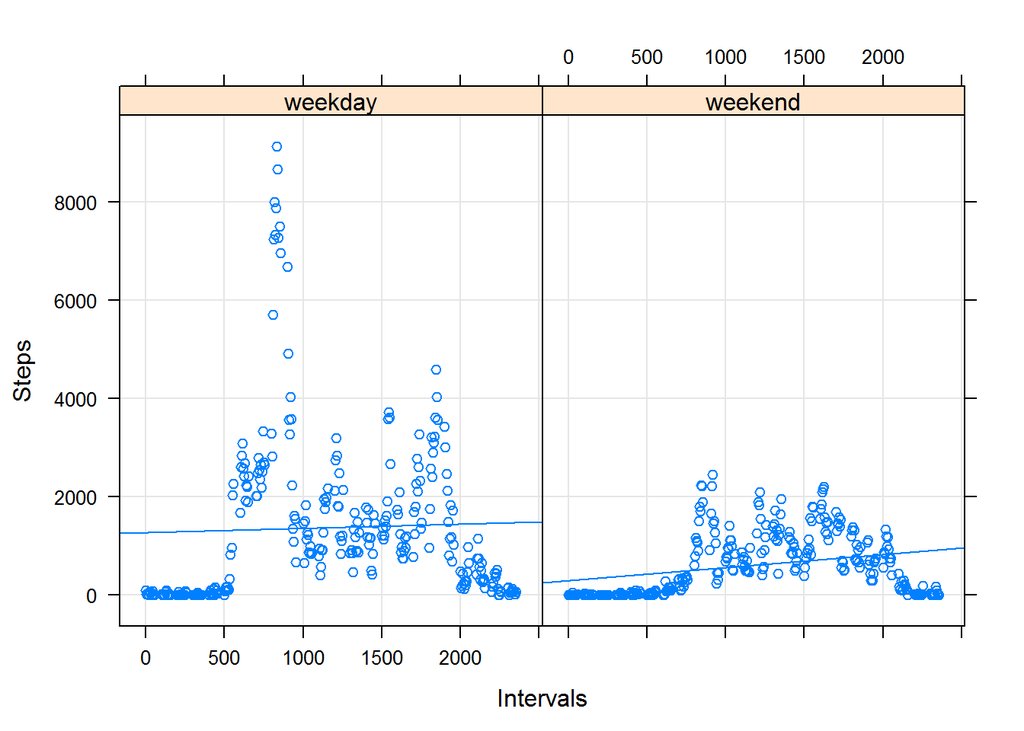

```r
xyplot(agg_ByStepsDayOfWeek$steps ~ agg_ByStepsDayOfWeek$interval|agg_ByStepsDayOfWeek$dayOfWeek, grid = TRUE, type = c("p", "r"), xlab = "Intervals", ylab = "Steps")
```